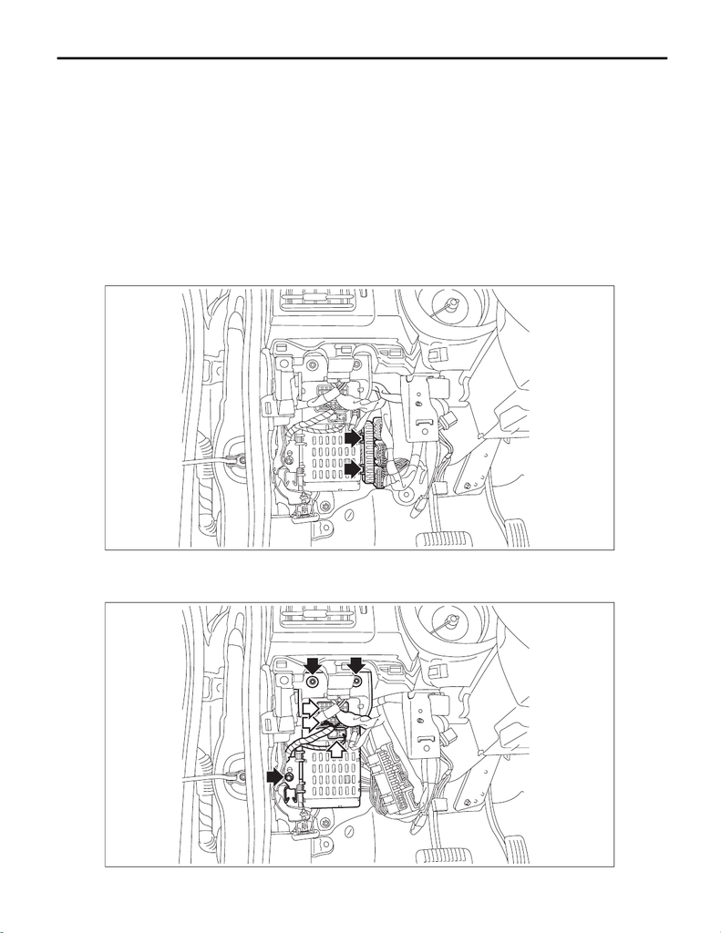

SL-100

Keyless Access CM

SECURITY AND LOCKS

33.Keyless Access CM

A: REMOVAL

CAUTION:

Before handling the airbag module, refer to “CAUTION” of “General Description” in “AIRBAG SYS-

TEM”. <Ref. to AB-9, CAUTION, General Description.>

1) Disconnect the ground cable from battery and wait for at least 60 seconds before starting work. <Ref. to

NT-5, BATTERY, NOTE, Note.>

NOTE:

For models other than STI model, disconnect the ground terminal from battery sensor.

2) Remove the cover assembly - instrument panel LWR driver. <Ref. to EI-61, REMOVAL, Instrument Panel

Lower Cover.>

3) Remove the knee airbag module. <Ref. to AB-35, REMOVAL, Knee Airbag Module.>

4) Release the lock and remove the fuse holder.

5) Remove the relay & fuse box.

(1) Disconnect the connector.

(2) Remove the bolts and nuts, and remove the relay & fuse box.

SL-01530

SL-01531

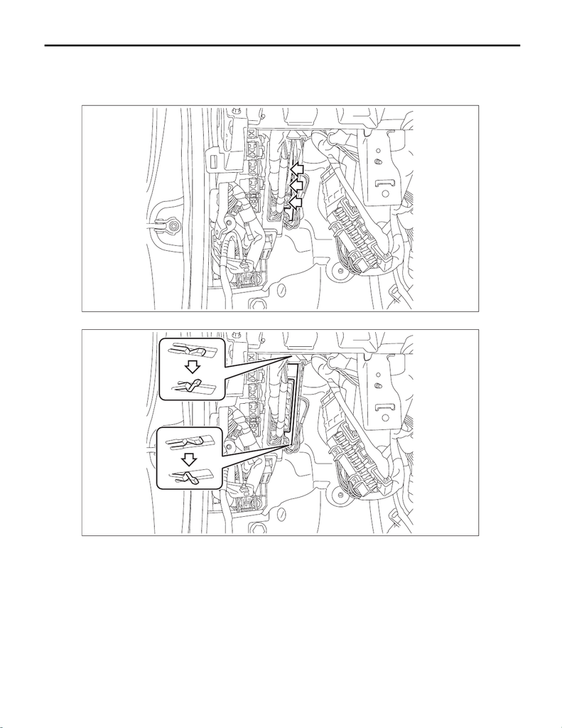

SL-101

Keyless Access CM

SECURITY AND LOCKS

6) Remove the keyless access CM.

CAUTION:

Be careful to keep water and other foreign materials away from body integrated unit.

(1) Disconnect the connector.

(2) Release the claws and pull out the keyless access CM.

SL-01622

SL-01623

[figure not shown]

SL-102

Keyless Access CM

SECURITY AND LOCKS

B: INSTALLATION

CAUTION:

• Registration of the immobilizer is necessary when a immobilizer-related control module has been

replaced. For detailed operation procedure, refer to the “REGISTRATION MANUAL FOR IMMOBILIZ-

ER”.

• Before handling the airbag module, refer to “CAUTION” of “General Description” in “AIRBAG SYS-

TEM”. <Ref. to AB-9, CAUTION, General Description.>

NOTE:

Make sure that there are no differences from the contents of the current settings after installation. <Ref. to

BC(diag)-15, LIST, Read Current Data.>

1) Install the keyless access CM.

2) Install the relay & fuse box and fuse holder.

Tightening torque:

Relay & fuse box: 7.5 N·m (0.8 kgf-m, 5.5 ft-lb)

3) Install the cover assembly - instrument panel LWR driver and the knee airbag module.

4) Connect the battery ground terminal. <Ref. to NT-5, BATTERY, NOTE, Note.>

NOTE:

For models other than STI model, connect the ground terminal to battery sensor.